# 3.1 Algoritma Pemrograman (Flowchart)

Algoritma adalah instruksi atau prosedur yang dituliskan secara terstruktur sehingga komputer dapat menjalankannya untuk menghasilkan output yang diinginkan. Terdapat tiga jenis algoritma :

1. Sequence
2. Branches (Selection)
3. Iteration (Loop)

### 3.1.1 Sequence (Urutan)

Pengertian: Sequence adalah algoritma yang langkah-langkahnya dijalankan secara berurutan, dari awal sampai akhir tanpa adanya percabangan atau pengulangan.

#### Ciri-ciri:

- Instruksi dieksekusi satu per satu.
- Tidak ada pilihan (if-else) atau perulangan.

#### Contoh:

Algoritma menghitung luas persegi panjang.

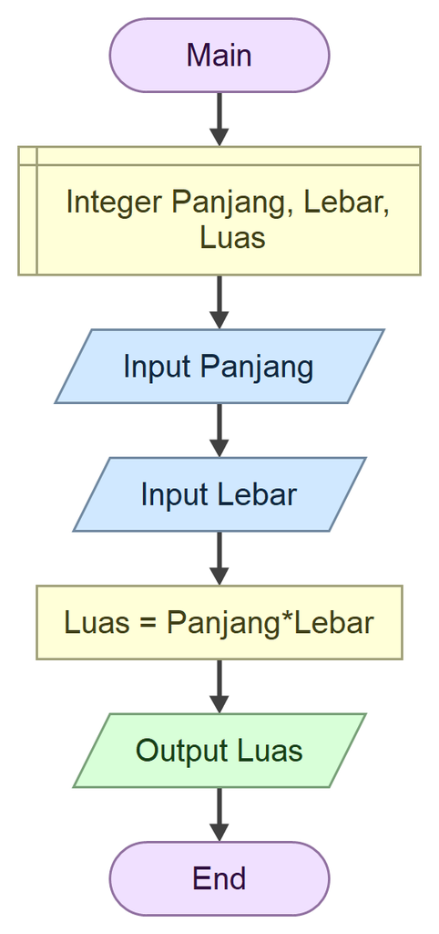

```python
from IPython.display import Image
Image("luas_persegi_panjang.png", width=250)
```

```python
# Program menghitung luas persegi panjang

# Input nilai dari user
panjang = int(input("Masukkan Panjang: "))
lebar = int(input("Masukkan Lebar: "))

# Proses menghitung luas
luas = panjang * lebar

# Output hasil
print("Luas Persegi Panjang adalah:", luas)
```

```
Luas Persegi Panjang adalah: 12
```

### 3.1.2 Branches / Selection (Percabangan)

Pengertian: Branches atau selection adalah algoritma yang memiliki kondisi tertentu untuk menentukan alur program, biasanya menggunakan struktur IF, IF-ELSE, atau CASE (Switch).

#### Ciri-ciri:

- Ada kondisi yang diperiksa.
- Program bisa mengikuti jalur berbeda sesuai hasil kondisi (benar/salah).

#### Contoh:

Algoritma menentukan bilangan ganjil/genap.

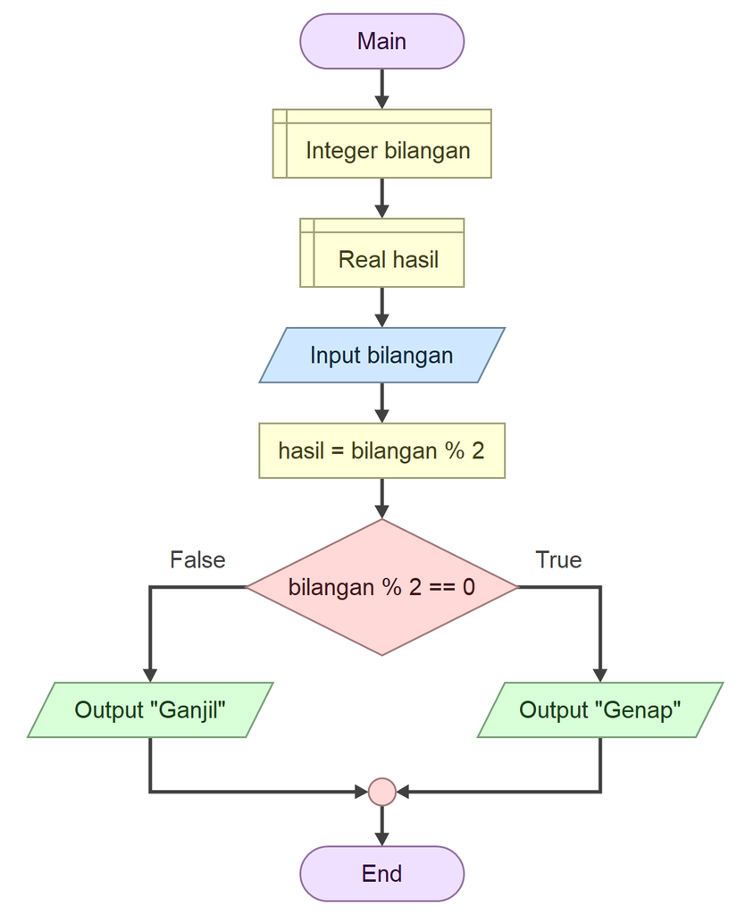

```python
Image("ganjil_genap.png", width=500)
```

```python
# Program cek bilangan ganjil atau genap

# Input bilangan
bilangan = int(input("Masukkan sebuah bilangan: "))

# Proses cek ganjil/genap
if bilangan % 2 == 0:
    print("Bilangan", bilangan, "adalah Genap")
else:
    print("Bilangan", bilangan, "adalah Ganjil")
```

```
Bilangan 4 adalah Genap
```

### 3.1.3 Iteration / Loop (Perulangan)

Pengertian: Iteration adalah algoritma yang mengeksekusi instruksi secara berulang sampai kondisi tertentu terpenuhi.

#### Ciri-ciri:

- Menggunakan struktur FOR, WHILE, atau DO-WHILE.
- Efektif untuk masalah yang membutuhkan pengulangan langkah.

#### Contoh:

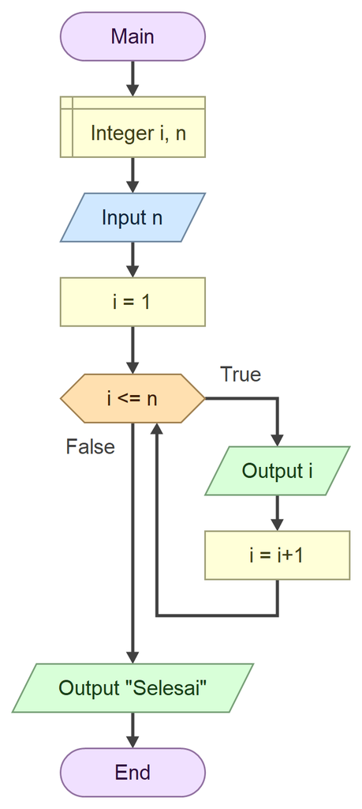

```python
Image("looping.png", width=300)
```

```python
# Program perulangan dengan input user

# input batas angka
n = int(input("Masukkan batas angka: "))
# nilai awal
i = 1

# kondisi perulangan
while i <= n:
    print(i)
    i = i + 1
```

```
1
2
3
```

## Flowchart

Flowchart adalah diagram yang menggunakan simbol standar untuk menggambarkan secara visual langkah-langkah dan keputusan dari suatu proses, sistem, atau program komputer. Diagram ini menghubungkan setiap langkah dengan garis atau panah untuk menunjukkan alur atau urutan yang harus diikuti. Flowchart membantu menyederhanakan proses, memudahkan pemahaman, mengidentifikasi kesalahan, dan meningkatkan efisiensi.

### Berikut adalah simbol-simbol yang terdapat pada flowchart :

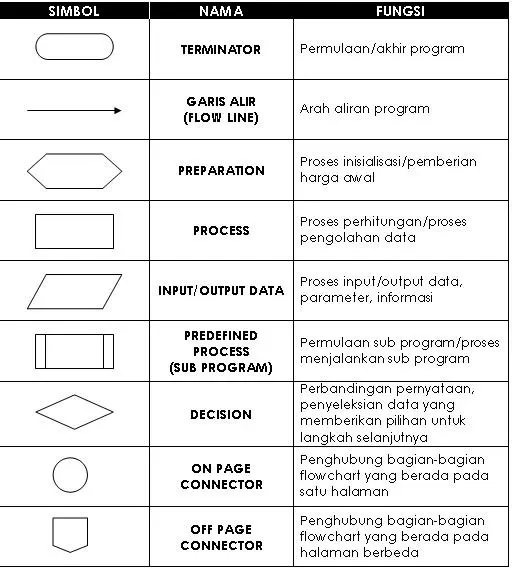

```python
Image("simbol.png", width=500)
```

### Latihan

#### Problem 1

Hitung kurs mata uang

- Input : pilihan menu
- Output : Kurs mata uang sesuai dengan pilihan user

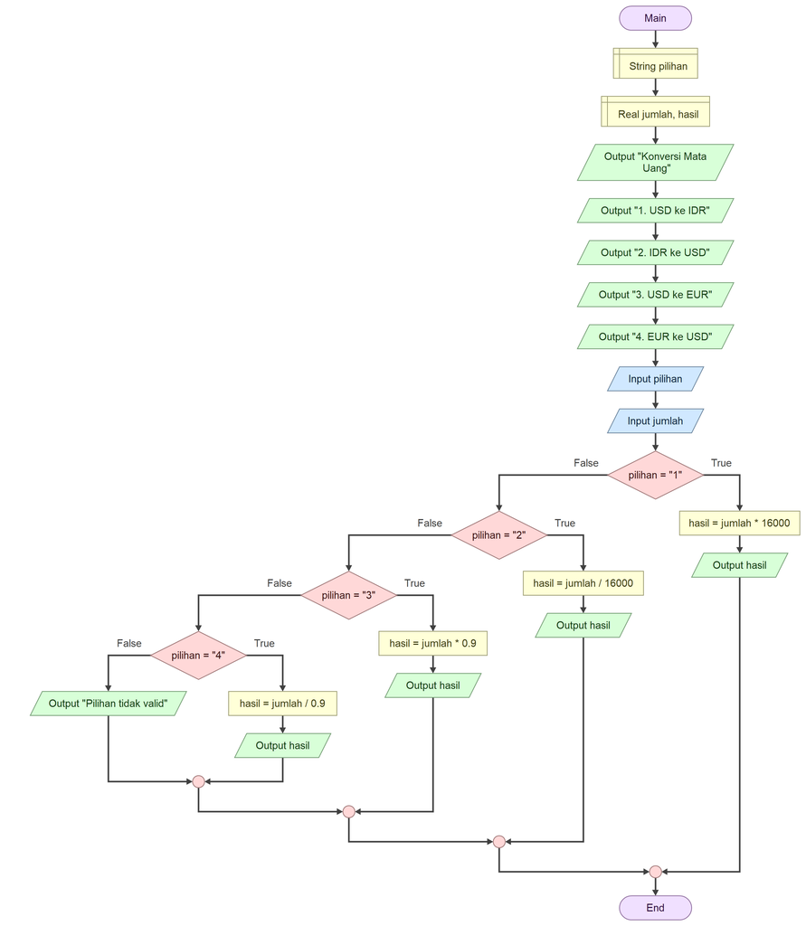

```python
Image("konversi_mata_uang.png", width=1200)
```

```python
print("Konversi Mata Uang")
print("1. USD ke IDR")
print("2. IDR ke USD")
print("3. USD ke EUR")
print("4. EUR ke USD")

pilihan = input("Masukkan pilihan (1/2/3/4): ")
jumlah = float(input("Masukkan jumlah uang: "))

if pilihan == "1":
    hasil = jumlah * 16000   # 1 USD = 15.000 IDR
    print("Hasil:", hasil, "IDR")

elif pilihan == "2":
    hasil = jumlah / 16000
    print("Hasil:", hasil, "USD")

elif pilihan == "3":
    hasil = jumlah * 0.9   # 1 USD = 0.9 EUR
    print("Hasil:", hasil, "EUR")

elif pilihan == "4":
    hasil = jumlah / 0.9
    print("Hasil:", hasil, "USD")

else:
    print("Pilihan tidak valid")
```

```
Konversi Mata Uang
1. USD ke IDR
2. IDR ke USD
3. USD ke EUR
4. EUR ke USD
```

```
Hasil: 32000.0 IDR
```

#### Problem 2

Hitung Luas berbagai macam bentuk (bujur sangkar, segitiga, dan lingkaran)

- Input : pilihan menu
- Output : Luas

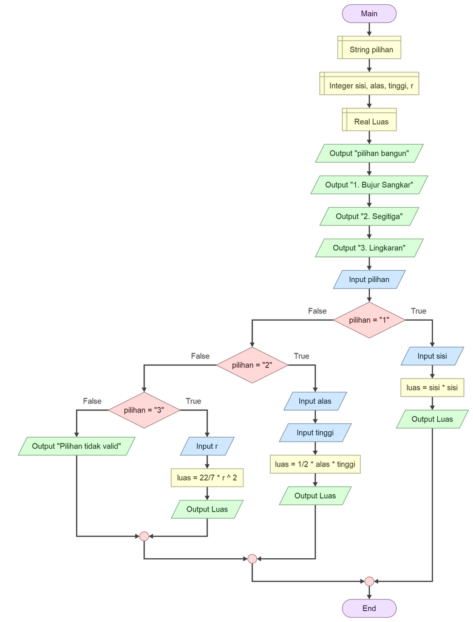

```python
Image("hitung_luas_fixed.png", width=1000)
```

```python
print("pilihan bangun")
print("1. Bujur sangkar")
print("2. Segitiga")
print("3. Lingkaran")
pilihan = input("pilihan (1/2/3)")


if pilihan == "1":
    sisi = int(input("Masukkan sisi: "))
    luas = sisi*sisi
    print("Luas Persegi adalah:", luas)

elif pilihan == "2":
    alas = int(input("Masukkan alas: "))
    tinggi = int(input("Masukkan tinggi: "))
    luas = 1/2*alas*tinggi
    print("Luas Segitiga adalah:", luas)

elif pilihan == "3":
    r = int(input("Masukkan r: "))
    luas = 22/7*r**2
    print("Luas Lingkaran adalah:", luas)

else:
    print("Pilihan tidak valid")
```

```
pilihan bangun
1. Bujur sangkar
2. Segitiga
3. Lingkaran
```

```
Luas Lingkaran adalah: 154.0
```

#### Problem 3

Tampilkan sejumlah n bilangan ganjil

- Input : n
- Output : bilangan ganjil sebanyak n buah

Buat flowchart dan program nya (NPM genap dengan menggunakan for, dan NPM Ganjil menggunakan while)

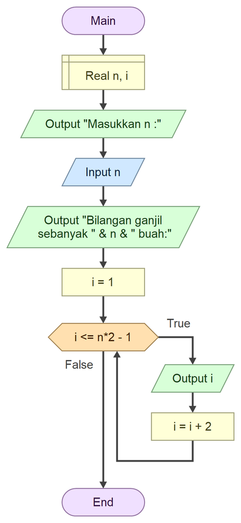

```python
Image("ganjil_while.png", width=300)
```

```python
print("Program Menampilkan n Bilangan Ganjil (WHILE)")
n = int(input("Masukkan jumlah n: "))

print("Bilangan ganjil sebanyak", n, "buah:")

i = 1
while i <= n*2 - 1:   # batas akhir = ganjil terbesar
    print(i)
    i += 2
```

```
Program Menampilkan n Bilangan Ganjil (WHILE)
```

```
Bilangan ganjil sebanyak 3 buah:
1
3
5
```

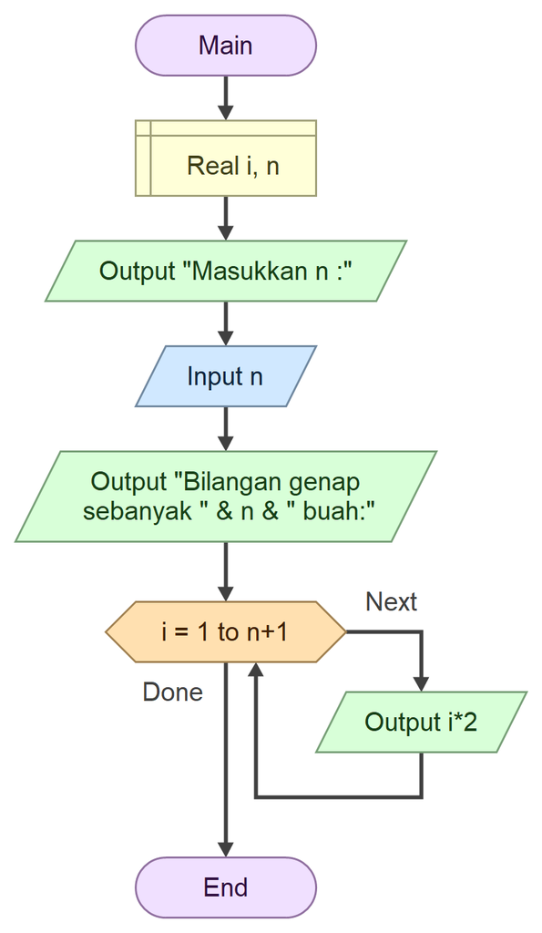

```python
Image("genap_for.png", width=300)
```

```python
print("Program Menampilkan n Bilangan Genap (FOR)")
n = int(input("Masukkan jumlah n: "))

print("Bilangan genap sebanyak", n, "buah:")
for i in range(1, n+1):   # i dari 1 sampai n
    print(i*2,)
```

```
Program Menampilkan n Bilangan Genap (FOR)
```

```
Bilangan genap sebanyak 3 buah:
2
4
6
```

#### Problem 4

Deret Matematika dengan pola (3/14, 9/18, 27/22, 81/26, 243/30, ...), tampilkan suku-suku pada deret matematika tersebut dengan syarat total penjumlahan semua suku lebih dari atau sama dengan nilai tertentu, yaitu total

- Input : total
- Output : bilangan pada deret matematika tersebut

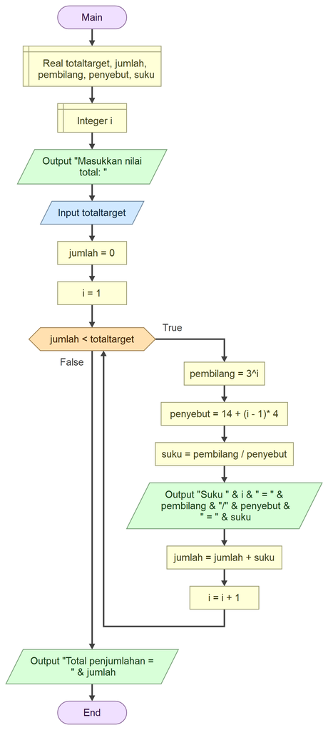

```python
Image("deret_matematika.png", width=400)
```

```python
print("Deret Matematika")
total_target = float(input("Masukkan nilai total: "))

jumlah = 0
i = 1
while jumlah < total_target:
    pembilang = 3**i
    penyebut = 14 + (i-1)*4
    suku = pembilang / penyebut
    print("Suku", i, "=", pembilang, "/", penyebut, "=", suku)
    jumlah += suku
    i += 1

print("Total penjumlahan =", jumlah)
```

```
Deret Matematika
```

```
Suku 1 = 3 / 14 = 0.21428571428571427
Suku 2 = 9 / 18 = 0.5
Suku 3 = 27 / 22 = 1.2272727272727273
Suku 4 = 81 / 26 = 3.1153846153846154
Total penjumlahan = 5.056943056943057
```

#### Problem 5

Deret matematika dengan pola sebagai berikut : 3/14, -4/28, 5/56, -6/112, 7/224, -8/448, 9/896, -10/1792

- Input : n
- Output : tampilkan deret matematika sebanyak n suku

[figure not shown]

```python
Image("deret_no5.png", width=400)
```

```python
print("Deret Matematika")
n = int(input("Masukkan jumlah n: "))

for i in range(1, n+1):
    pembilang = (i + 2)
    # tambahkan tanda negatif tiap suku genap
    if i % 2 == 0:
        pembilang = -pembilang
    penyebut = 14 * (2**(i-1))
    print("Suku", i, "=", pembilang, "/", penyebut)
```

```
Deret Matematika
```

```
Suku 1 = 3 / 14
Suku 2 = -4 / 28
Suku 3 = 5 / 56
Suku 4 = -6 / 112
```

#### Problem 6

- Buat flowchart dan program untuk menampilkan deret matematika sebagai berikut : suku ke- 1 = 3 suku ke- 2 = 9 suku ke- 3 = 27 suku ke- 4 = 81 , ...
- Tampilkan deret tersebut sampai suku tertentu (n) atau total penjumlahan dari deret tersebut kurang dari atau sama dengan nilai tertentu (jumlah)
- Input : n dan jumlah

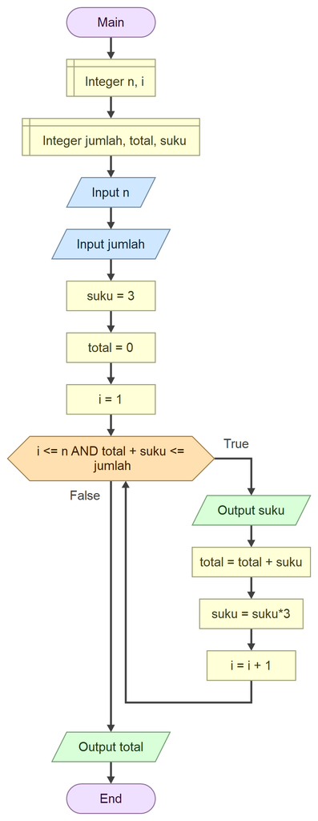

```python
Image("flowchart_no6.png", width=350)
```

```python
# Input dari pengguna
n = int(input("Masukkan jumlah suku (n): "))
jumlah = int(input("Masukkan total maksimal penjumlahan: "))

suku = 3
total = 0
i = 1

print("Deret yang dihasilkan:")

while i <= n and total + suku <= jumlah:
    print(suku, end=" ")
    total += suku
    suku *= 3
    i += 1

print("\nTotal penjumlahan:", total)
```

```
Deret yang dihasilkan:
3 9 27 81 243
Total penjumlahan: 363
```